# Day 3 Lecture

# Review Day 2 Practice & Homework

# Questions?

## Working directory

```r
#getwd() #what is the working directory?
#setwd() #sets the working directory
```

# R Markdown vs. scripts

Sweave: the original “reproducible document”, mix of LaTeX and R

R Markdown: one of the “cutting edge” formats, especially well-integrated into RStudio, that allows mixing of R code with text, document formatting, links, graphics, etc.

The following is a code chunk, and when `knitr()` is run on this document, it will display both the code and the output.

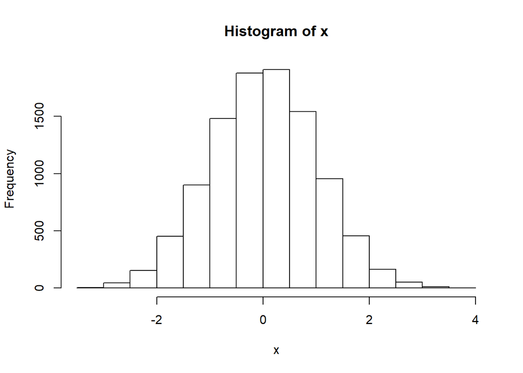

```r
x <- rnorm(10000)
hist(x)  # this is a histogram
```

```r
t.test(x)
```

```
##
##  One Sample t-test
##
## data:  x
## t = 1.7252, df = 9999, p-value = 0.08452
## alternative hypothesis: true mean is not equal to 0
## 95 percent confidence interval:
##  -0.002336487  0.036641339
## sample estimates:
##  mean of x
## 0.01715243
```

You can also insert “inline” results, like the following:

The mean of `x` is 0.0171524.

More documentation on Markdown and R Markdown: Help > Markdown Quick Reference Help > RStudio Docs

# Environments and `save()`/`load()`

- the basic R “workspace” is the Global Environment
  - aka `.GlobalEnv`
- “save workspace image?” question
  - recommend: no
  - not reproducible
  - helps perpetuate “bad programming hygiene”
  - ends up in .RData file (no name in front of .RData)
- *BEST PRACTICE*:
  - save code in script/notebook
  - save data in (non-proprietary) simple formats (CSV, etc.)
  - helps transparency, reproducibility, portability
- HOWEVER:
  - sometimes the result of an R function has non-trivial overhead (time)
  - *for convenience*, it can be handy to save R objects in a “native” format
  - `save()` then later `load()`

```r
#x <- rnorm(100, mean = 0, sd = 2)
#y <- rnorm(100, mean = 1, sd = 1)
#ttest.results <- t.test(x, y)
#ttest.results

## what if ttest.results took minutes/hours to compute?
#save(ttest.results, file = "big important object.RData")
#ttest.results
#rm(ttest.results) #removes the object
#ttest.results #see, it's gone!
#load("big important object.RData")    ##loads it, but note that the name of the object is the same as                                        before, and not the name as the object necessarily. After doing                                        the save, recommendin commenting everything out up until the load                                       (i.e. keep the code there, but dont' run it)
#ttest.results

#save.image() # saves the *entire* workspace in .RData
#save.image(file = "workspace.RData") # allows you to specify a name for the file
                                     # not loaded by default
```

# Reading and writing data/files

## Basic concepts:

- not “opening” files, but rather:
  - “reading” means “pulling data from a file into the workspace”
  - “writing” means “writing data from the workspace into a file”
- approach:
  1. Read data from whatever sources you need (from local files, from internet, whatever)
  2. Work with data in R (workspace)
  3. Write out whatever files you want to
  - updated/cleaned data
  - table of results/coefficients
  - plots
  - whatever you want! (and can program)

## Weird file types

Package for reading Excel data (contains arguments for which sheet, etc): `readxl`

- makes it easier to deal with Excel (esp .xslx files) without needing to export to CSV

Package for other stats packages (SPSS, SAS, Stata): `haven`

“Tidyverse” package for reading various kinds of data: `readr`

## Look at the options!

```r
?read.table

mydata <- read.csv(filename, na.strings = c("NA", "N/A", "n/a", " ", "nuthin"))

?readLines
?scan
```

## Writing files

```r
?write.table # .csv, etc.
```

Gotcha: - rownames!

```r
write.table(mydata, file = "outputfile.txt",
            sep = "\t",   # this makes the output tab-delimited
            row.names = FALSE)  # good for exporting data

write.csv(mydata, file = "outputfile.csv", row.names = FALSE) # good for writing CSVs
```

# Data types

- numeric
- logical
- character
- factor
- NA
- NULL
- others (e.g, “Date”)

## Numeric

- numbers!
- sometimes integers can differ from non-integers
- `as.numeric()` forces it to be a number (not integers)
- `1L` is an integer
- have mean, medians

A few handy things with numbers:

```r
# floating point pitfalls
x = 0.1 + 0.2
x
```

```
## [1] 0.3
```

```r
x == 0.3
```

```
## [1] FALSE
```

```r
# "e" notation for really big numbers
1e4
```

```
## [1] 10000
```

```r
# round() - round it to a specified number of decimal points
x2 = round(x, 1)
x2
```

```
## [1] 0.3
```

```r
# floor() - round down
# ceiling() - round up


# sample() - takes a random sample, doesn't have to be with numbers)
# rnorm() - numbers pulled from random distribution
# rbinom() - randomly pulled from a binomial distribution

rbinom(10, size = 10, prob = 0.2) #flip 10 coins, count how many successes i got, and do that ten                                   times (ten runs of ten coin flips)
```

```
##  [1] 3 3 1 0 3 1 1 2 0 3
```

```r
# the r/p/d/q families

# quantile()
```

## Logicals

- TRUE and FALSE
- if coerced to `as.numeric`, TRUE == 1, FALSE == 0
  - can take the mean of a logical vector
- Shortcuts: T and F
  - *DANGER*: T and F can be overwritten
- logical operators create logical vectors
  - `==`
  - `>`
  - `<`
  - `|` This is the “long bar”, meaning (inclusive) “or” (aka “pipe”)
  - `&` == “and”
  - `>=` greater or equal
  - `!` is NOT
  - `&&` and `||` for more specific programming situations

```r
# basic forms

# class() - tells you what class sit is, i.e numeric, character, etc

x = 1:5
x <= 3
```

```
## [1]  TRUE  TRUE  TRUE FALSE FALSE
```

```r
#in practice, we use the & and | to join things.

x = 1:6
x > 3
```

```
## [1] FALSE FALSE FALSE  TRUE  TRUE  TRUE
```

```r
x < 4
```

```
## [1]  TRUE  TRUE  TRUE FALSE FALSE FALSE
```

```r
(x > 2) & (x < 5) #parentheses not totally necessary here
```

```
## [1] FALSE FALSE  TRUE  TRUE FALSE FALSE
```

```r
x > 2
```

```
## [1] FALSE FALSE  TRUE  TRUE  TRUE  TRUE
```

```r
!x > 2
```

```
## [1]  TRUE  TRUE FALSE FALSE FALSE FALSE
```

```r
!(x > 4 | x < 3)
```

```
## [1] FALSE FALSE  TRUE  TRUE FALSE FALSE
```

```r
# "shortcut" forms (avoid!)

# examples of comparisons
1 == 2  #== also works for strings
```

```
## [1] FALSE
```

```r
# which()

x = sample (1:10, 100, replace = TRUE)
x == 7
```

```
##   [1] FALSE FALSE FALSE FALSE FALSE FALSE FALSE FALSE FALSE FALSE FALSE
##  [12] FALSE FALSE FALSE FALSE  TRUE FALSE FALSE FALSE FALSE  TRUE  TRUE
##  [23] FALSE  TRUE FALSE FALSE FALSE FALSE FALSE FALSE  TRUE FALSE FALSE
##  [34] FALSE  TRUE FALSE  TRUE  TRUE FALSE  TRUE FALSE FALSE FALSE FALSE
##  [45] FALSE FALSE FALSE FALSE FALSE FALSE FALSE FALSE  TRUE FALSE  TRUE
##  [56] FALSE  TRUE FALSE FALSE FALSE FALSE FALSE FALSE FALSE FALSE FALSE
##  [67] FALSE FALSE FALSE FALSE FALSE FALSE FALSE FALSE FALSE FALSE FALSE
##  [78] FALSE FALSE FALSE FALSE FALSE FALSE FALSE FALSE  TRUE FALSE FALSE
##  [89] FALSE FALSE FALSE FALSE FALSE FALSE FALSE FALSE FALSE FALSE FALSE
## [100] FALSE
```

```r
which (x==7)
```

```
##  [1] 16 21 22 24 31 35 37 38 40 53 55 57 86
```

```r
# logicals for subsetting

# %in%
all.values = c("a", "b", "c", "d")
x = sample(all.values, 100, TRUE)
x
```

```
##   [1] "d" "b" "c" "a" "d" "c" "c" "b" "a" "c" "b" "a" "a" "b" "b" "c" "c"
##  [18] "d" "a" "b" "a" "b" "d" "c" "d" "c" "b" "d" "d" "a" "a" "a" "d" "c"
##  [35] "a" "c" "b" "b" "b" "d" "c" "b" "b" "b" "a" "b" "a" "d" "c" "d" "d"
##  [52] "a" "c" "b" "b" "a" "c" "c" "b" "b" "d" "b" "d" "a" "a" "c" "a" "b"
##  [69] "d" "b" "c" "b" "b" "d" "b" "c" "b" "d" "b" "c" "d" "b" "b" "b" "c"
##  [86] "c" "d" "a" "d" "c" "d" "a" "c" "b" "d" "a" "d" "d" "d" "c"
```

```r
#we want to know where the a's and b's are

x == c("a", "b") #not the right way! (checks if the first is a, second is b, third is a, etc)
```

```
##   [1] FALSE  TRUE FALSE FALSE FALSE FALSE FALSE  TRUE  TRUE FALSE FALSE
##  [12] FALSE  TRUE  TRUE FALSE FALSE FALSE FALSE  TRUE  TRUE  TRUE  TRUE
##  [23] FALSE FALSE FALSE FALSE FALSE FALSE FALSE FALSE  TRUE FALSE FALSE
##  [34] FALSE  TRUE FALSE FALSE  TRUE FALSE FALSE FALSE  TRUE FALSE  TRUE
##  [45]  TRUE  TRUE  TRUE FALSE FALSE FALSE FALSE FALSE FALSE  TRUE FALSE
##  [56] FALSE FALSE FALSE FALSE  TRUE FALSE  TRUE FALSE FALSE  TRUE FALSE
##  [67]  TRUE  TRUE FALSE  TRUE FALSE  TRUE FALSE FALSE FALSE FALSE FALSE
##  [78] FALSE FALSE FALSE FALSE  TRUE FALSE  TRUE FALSE FALSE FALSE FALSE
##  [89] FALSE FALSE FALSE FALSE FALSE  TRUE FALSE FALSE FALSE FALSE FALSE
## [100] FALSE
```

```r
x %in% c("a", "b") # this is the right way (checks a and b for each one)
```

```
##   [1] FALSE  TRUE FALSE  TRUE FALSE FALSE FALSE  TRUE  TRUE FALSE  TRUE
##  [12]  TRUE  TRUE  TRUE  TRUE FALSE FALSE FALSE  TRUE  TRUE  TRUE  TRUE
##  [23] FALSE FALSE FALSE FALSE  TRUE FALSE FALSE  TRUE  TRUE  TRUE FALSE
##  [34] FALSE  TRUE FALSE  TRUE  TRUE  TRUE FALSE FALSE  TRUE  TRUE  TRUE
##  [45]  TRUE  TRUE  TRUE FALSE FALSE FALSE FALSE  TRUE FALSE  TRUE  TRUE
##  [56]  TRUE FALSE FALSE  TRUE  TRUE FALSE  TRUE FALSE  TRUE  TRUE FALSE
##  [67]  TRUE  TRUE FALSE  TRUE FALSE  TRUE  TRUE FALSE  TRUE FALSE  TRUE
##  [78] FALSE  TRUE FALSE FALSE  TRUE  TRUE  TRUE FALSE FALSE FALSE  TRUE
##  [89] FALSE FALSE FALSE  TRUE FALSE  TRUE FALSE  TRUE FALSE FALSE FALSE
## [100] FALSE
```

PRACTICE! #0 – #2 in the “day03_practice.Rmd” file

Try “knitting” the result!

## Characters

- `as.character()` converts to characters
- more primitive than factors
- can manipulate with regular expressions, other text functions

Some handy text stuff

```r
# cat(), print()

# special characters: \t, \n, "escaping"

# nchar()

# paste(), strsplit()

# stringr package

# grep(), grepl(), gsub()
```

## Factors

- Actually numbers under the hood
- Act like numbers + labels
- VERY useful for many kinds of analyses
- if a column is a *property* of data (not a measure itself), factors are usually best
  - groupings = good as factors
  - conditions = good as factors
- if a column is *data*, maybe consider keeping it a string
  - free response answers = bad as factors
- `as.factor()` coerces to a factor
- `factor()` creates a factor
- factors have *levels*: categories
- `stringsAsFactors` : option for how to read in character vectors
  - = FALSE if you don’t want to read in characters as factors

```r
# factor()

# levels()

# summary()

# coersion

# subsetting

# droplevels

# changing levels (labels)

# re-ordering
```

PRACTICE: #3, #4, #5

## Data manipulation excursion

### Creating (simple) new columns

```r
# single value

# using subsetting
```

### Using xtabs() to check coding/cross-tabs

# NAs, NULLs

## NAs

- missing data
- can be a huge pain
- hugely important to handle properly!
- no universal “handle NAs” or “ignore NAs” argument
- sometimes `na.rm = TRUE` (like for `mean()`)
- sometimes it’s other stuff
- `cor()` use = “pairwise.complete.obs”
- no universal “deal with NAs” argument

```r
x <- c(1, 2, NA, 4, 68)
mean(x)
```

```
## [1] NA
```

```r
mean(x, na.rm = TRUE)
```

```
## [1] 18.75
```

```r
y <- c(NA, 4, 23, 2, 6)

cor(x, y)
```

```
## [1] NA
```

```r
cor(x, y, use = "complete.obs")
```

```
## [1] 0.8523994
```

```r
x.1 <- c(2, 4, 68)
y.1 <- c(4, 2, 6)
cor(x.1, y.1)
```

```
## [1] 0.8523994
```

```r
x == NA
```

```
## [1] NA NA NA NA NA
```

```r
is.na(x)
```

```
## [1] FALSE FALSE  TRUE FALSE FALSE
```

```r
!is.na(x)
```

```
## [1]  TRUE  TRUE FALSE  TRUE  TRUE
```

## NULL

- another special value
- means “nothing” or “doesn’t exist” (contrast with “missing” or “unknown”)

## Inf, -Inf, NaN

- can sometimes result from mathematical operations
- helpful to be able to identify, locate them

```r
x <- 1/0
y <- -1/0
z <- sqrt(-4)
x
```

```
## [1] Inf
```

```r
y
```

```
## [1] -Inf
```

```r
z
```

```
## [1] NaN
```

```r
is.finite(x)
```

```
## [1] FALSE
```

```r
is.finite(y)
```

```
## [1] FALSE
```

```r
is.finite(z)
```

```
## [1] FALSE
```

```r
is.finite(NA)
```

```
## [1] FALSE
```

```r
is.infinite(x)
```

```
## [1] TRUE
```

```r
is.infinite(y)
```

```
## [1] TRUE
```

```r
is.infinite(z)
```

```
## [1] FALSE
```

```r
is.infinite(NA)
```

```
## [1] FALSE
```

```r
is.nan(x)
```

```
## [1] FALSE
```

```r
is.nan(y)
```

```
## [1] FALSE
```

```r
is.nan(z)
```

```
## [1] TRUE
```

```r
is.nan(NA)
```

```
## [1] FALSE
```

```r
is.na(x)
```

```
## [1] FALSE
```

```r
is.na(y)
```

```
## [1] FALSE
```

```r
is.na(z) # surprising to me
```

```
## [1] TRUE
```

```r
is.na(NA)
```

```
## [1] TRUE
```

## Generic functions

```r
#scottdata <- read.csv("scottdata/CognitionPaperModifiedData.csv")
#summary(scottdata)
#summary(scottdata$Corpus)
#example.lm <- lm(HiSegType ~ LoSegType, data = scottdata)
#summary(example.lm)
#class(scottdata)
#class(scottdata$Corpus)
#class(example.lm)
```

# Data types, classes, & coersion

```r
# typeof()

# class()
```

`is.X` family of functions (`is.factor()`, `is.na()`, `is.finite()`, etc.) `as.X` family of functions (`as.factor()`, `as.numeric()`, `as.data.frame()`, etc.)

# Lists

- similar to vectors
- can contain different data types
- use [[ ]] to pull out values
- handy for glomming large/complex objects together
- data frames are special lists!

# Creating data frames

- handy, especially for making “look-up tables”

```r
# data.frame()
```

# Combining data sets

## Combining data frame objects

### `rbind()` and `cbind()`

- rbind
  - glues rows on top of each other
  - expects same columns
  - new and improved `bind_rows()` in `dplyr` package
- cbind
  - glues columns next to each other
  - need to be the same length

### `merge()` and `*_join()` from `dplyr` package

```
- simplest: have ONE column in common, named the same thing (with the same values)
- can get MUCH more complex
- `nrow()` good check on what was gained/lost during a merge
- "join" functions in `dplyr`
  - `inner_join()` is like all = FALSE
  - `full_join()` is like all = TRUE
  - `left_join()`, `right_join()`, etc.
  - see ?join for more details
```